# Risk Factor Analysis

## Outcome Variable

**Outcome Variable:** sstunted

## Predictor Variables

**Intervention Variable:** enstunt

**Adjustment Set:**

unadjusted

## Stratifying Variables

The analysis was stratified on these variable(s):

- agecat
- studyid
- country

## Data Summary

| agecat | studyid | country | enstunt | sstunted | n_cell | n |
| --- | --- | --- | --- | --- | --- | --- |
| Birth | CMC-V-BCS-2002 | INDIA | 0 | 0 | 75 | 92 |
| Birth | CMC-V-BCS-2002 | INDIA | 0 | 1 | 0 | 92 |
| Birth | CMC-V-BCS-2002 | INDIA | 1 | 0 | 13 | 92 |
| Birth | CMC-V-BCS-2002 | INDIA | 1 | 1 | 4 | 92 |
| Birth | CMIN | BANGLADESH | 0 | 0 | 17 | 26 |
| Birth | CMIN | BANGLADESH | 0 | 1 | 0 | 26 |
| Birth | CMIN | BANGLADESH | 1 | 0 | 3 | 26 |
| Birth | CMIN | BANGLADESH | 1 | 1 | 6 | 26 |
| Birth | COHORTS | GUATEMALA | 0 | 0 | 802 | 852 |
| Birth | COHORTS | GUATEMALA | 0 | 1 | 0 | 852 |
| Birth | COHORTS | GUATEMALA | 1 | 0 | 39 | 852 |
| Birth | COHORTS | GUATEMALA | 1 | 1 | 11 | 852 |
| Birth | COHORTS | INDIA | 0 | 0 | 5848 | 6640 |
| Birth | COHORTS | INDIA | 0 | 1 | 0 | 6640 |
| Birth | COHORTS | INDIA | 1 | 0 | 586 | 6640 |
| Birth | COHORTS | INDIA | 1 | 1 | 206 | 6640 |
| Birth | COHORTS | PHILIPPINES | 0 | 0 | 2863 | 3050 |
| Birth | COHORTS | PHILIPPINES | 0 | 1 | 0 | 3050 |
| Birth | COHORTS | PHILIPPINES | 1 | 0 | 141 | 3050 |
| Birth | COHORTS | PHILIPPINES | 1 | 1 | 46 | 3050 |
| Birth | CONTENT | PERU | 0 | 0 | 2 | 2 |
| Birth | CONTENT | PERU | 0 | 1 | 0 | 2 |
| Birth | CONTENT | PERU | 1 | 0 | 0 | 2 |
| Birth | CONTENT | PERU | 1 | 1 | 0 | 2 |
| Birth | EE | PAKISTAN | 0 | 0 | 140 | 240 |
| Birth | EE | PAKISTAN | 0 | 1 | 0 | 240 |
| Birth | EE | PAKISTAN | 1 | 0 | 52 | 240 |
| Birth | EE | PAKISTAN | 1 | 1 | 48 | 240 |
| Birth | GMS-Nepal | NEPAL | 0 | 0 | 574 | 696 |
| Birth | GMS-Nepal | NEPAL | 0 | 1 | 0 | 696 |

[output cut: 298 more lines]

The following strata were considered:

- agecat: 24 months, studyid: CMC-V-BCS-2002, country: INDIA
- agecat: 24 months, studyid: CMIN, country: BANGLADESH
- agecat: 24 months, studyid: COHORTS, country: GUATEMALA
- agecat: 24 months, studyid: COHORTS, country: INDIA
- agecat: 24 months, studyid: COHORTS, country: PHILIPPINES
- agecat: 24 months, studyid: CONTENT, country: PERU
- agecat: 24 months, studyid: EE, country: PAKISTAN
- agecat: 24 months, studyid: GMS-Nepal, country: NEPAL
- agecat: 24 months, studyid: IRC, country: INDIA
- agecat: 24 months, studyid: JiVitA-3, country: BANGLADESH
- agecat: 24 months, studyid: JiVitA-4, country: BANGLADESH
- agecat: 24 months, studyid: Keneba, country: GAMBIA
- agecat: 24 months, studyid: LCNI-5, country: MALAWI
- agecat: 24 months, studyid: MAL-ED, country: BANGLADESH
- agecat: 24 months, studyid: MAL-ED, country: BRAZIL
- agecat: 24 months, studyid: MAL-ED, country: INDIA
- agecat: 24 months, studyid: MAL-ED, country: NEPAL
- agecat: 24 months, studyid: MAL-ED, country: PERU
- agecat: 24 months, studyid: MAL-ED, country: SOUTH AFRICA
- agecat: 24 months, studyid: MAL-ED, country: TANZANIA, UNITED REPUBLIC OF
- agecat: 24 months, studyid: NIH-Birth, country: BANGLADESH
- agecat: 24 months, studyid: NIH-Crypto, country: BANGLADESH
- agecat: 24 months, studyid: PROBIT, country: BELARUS
- agecat: 24 months, studyid: PROVIDE, country: BANGLADESH
- agecat: 24 months, studyid: TanzaniaChild2, country: TANZANIA, UNITED REPUBLIC OF
- agecat: 24 months, studyid: ZVITAMBO, country: ZIMBABWE
- agecat: 6 months, studyid: CMC-V-BCS-2002, country: INDIA
- agecat: 6 months, studyid: CMIN, country: BANGLADESH
- agecat: 6 months, studyid: COHORTS, country: GUATEMALA
- agecat: 6 months, studyid: COHORTS, country: INDIA
- agecat: 6 months, studyid: COHORTS, country: PHILIPPINES
- agecat: 6 months, studyid: CONTENT, country: PERU
- agecat: 6 months, studyid: EE, country: PAKISTAN
- agecat: 6 months, studyid: GMS-Nepal, country: NEPAL
- agecat: 6 months, studyid: Guatemala BSC, country: GUATEMALA
- agecat: 6 months, studyid: IRC, country: INDIA
- agecat: 6 months, studyid: JiVitA-3, country: BANGLADESH
- agecat: 6 months, studyid: JiVitA-4, country: BANGLADESH
- agecat: 6 months, studyid: Keneba, country: GAMBIA
- agecat: 6 months, studyid: LCNI-5, country: MALAWI
- agecat: 6 months, studyid: MAL-ED, country: BANGLADESH
- agecat: 6 months, studyid: MAL-ED, country: BRAZIL
- agecat: 6 months, studyid: MAL-ED, country: INDIA
- agecat: 6 months, studyid: MAL-ED, country: NEPAL
- agecat: 6 months, studyid: MAL-ED, country: PERU
- agecat: 6 months, studyid: MAL-ED, country: SOUTH AFRICA
- agecat: 6 months, studyid: MAL-ED, country: TANZANIA, UNITED REPUBLIC OF
- agecat: 6 months, studyid: NIH-Birth, country: BANGLADESH
- agecat: 6 months, studyid: NIH-Crypto, country: BANGLADESH
- agecat: 6 months, studyid: PROBIT, country: BELARUS
- agecat: 6 months, studyid: PROVIDE, country: BANGLADESH
- agecat: 6 months, studyid: ResPak, country: PAKISTAN
- agecat: 6 months, studyid: SAS-CompFeed, country: INDIA
- agecat: 6 months, studyid: SAS-FoodSuppl, country: INDIA
- agecat: 6 months, studyid: TanzaniaChild2, country: TANZANIA, UNITED REPUBLIC OF
- agecat: 6 months, studyid: ZVITAMBO, country: ZIMBABWE
- agecat: Birth, studyid: CMC-V-BCS-2002, country: INDIA
- agecat: Birth, studyid: CMIN, country: BANGLADESH
- agecat: Birth, studyid: COHORTS, country: GUATEMALA
- agecat: Birth, studyid: COHORTS, country: INDIA
- agecat: Birth, studyid: COHORTS, country: PHILIPPINES
- agecat: Birth, studyid: CONTENT, country: PERU
- agecat: Birth, studyid: EE, country: PAKISTAN
- agecat: Birth, studyid: GMS-Nepal, country: NEPAL
- agecat: Birth, studyid: IRC, country: INDIA
- agecat: Birth, studyid: JiVitA-3, country: BANGLADESH
- agecat: Birth, studyid: JiVitA-4, country: BANGLADESH
- agecat: Birth, studyid: Keneba, country: GAMBIA
- agecat: Birth, studyid: MAL-ED, country: BANGLADESH
- agecat: Birth, studyid: MAL-ED, country: BRAZIL
- agecat: Birth, studyid: MAL-ED, country: INDIA
- agecat: Birth, studyid: MAL-ED, country: NEPAL
- agecat: Birth, studyid: MAL-ED, country: PERU
- agecat: Birth, studyid: MAL-ED, country: SOUTH AFRICA
- agecat: Birth, studyid: MAL-ED, country: TANZANIA, UNITED REPUBLIC OF
- agecat: Birth, studyid: NIH-Birth, country: BANGLADESH
- agecat: Birth, studyid: NIH-Crypto, country: BANGLADESH
- agecat: Birth, studyid: PROBIT, country: BELARUS
- agecat: Birth, studyid: PROVIDE, country: BANGLADESH
- agecat: Birth, studyid: ResPak, country: PAKISTAN
- agecat: Birth, studyid: SAS-CompFeed, country: INDIA
- agecat: Birth, studyid: ZVITAMBO, country: ZIMBABWE

### Dropped Strata

Some strata were dropped due to rare outcomes:

- agecat: Birth, studyid: CMC-V-BCS-2002, country: INDIA
- agecat: Birth, studyid: CMIN, country: BANGLADESH
- agecat: Birth, studyid: COHORTS, country: GUATEMALA
- agecat: Birth, studyid: COHORTS, country: INDIA
- agecat: Birth, studyid: COHORTS, country: PHILIPPINES
- agecat: Birth, studyid: CONTENT, country: PERU
- agecat: Birth, studyid: EE, country: PAKISTAN
- agecat: Birth, studyid: GMS-Nepal, country: NEPAL
- agecat: Birth, studyid: IRC, country: INDIA
- agecat: Birth, studyid: JiVitA-3, country: BANGLADESH
- agecat: Birth, studyid: JiVitA-4, country: BANGLADESH
- agecat: Birth, studyid: Keneba, country: GAMBIA
- agecat: Birth, studyid: MAL-ED, country: BANGLADESH
- agecat: Birth, studyid: MAL-ED, country: BRAZIL
- agecat: Birth, studyid: MAL-ED, country: INDIA
- agecat: Birth, studyid: MAL-ED, country: NEPAL
- agecat: Birth, studyid: MAL-ED, country: PERU
- agecat: Birth, studyid: MAL-ED, country: SOUTH AFRICA
- agecat: Birth, studyid: MAL-ED, country: TANZANIA, UNITED REPUBLIC OF
- agecat: Birth, studyid: NIH-Birth, country: BANGLADESH
- agecat: Birth, studyid: NIH-Crypto, country: BANGLADESH
- agecat: Birth, studyid: PROBIT, country: BELARUS
- agecat: Birth, studyid: PROVIDE, country: BANGLADESH
- agecat: Birth, studyid: ResPak, country: PAKISTAN
- agecat: Birth, studyid: SAS-CompFeed, country: INDIA
- agecat: Birth, studyid: ZVITAMBO, country: ZIMBABWE
- agecat: 6 months, studyid: CMIN, country: BANGLADESH
- agecat: 6 months, studyid: CONTENT, country: PERU
- agecat: 6 months, studyid: Guatemala BSC, country: GUATEMALA
- agecat: 6 months, studyid: LCNI-5, country: MALAWI
- agecat: 6 months, studyid: MAL-ED, country: BANGLADESH
- agecat: 6 months, studyid: MAL-ED, country: BRAZIL
- agecat: 6 months, studyid: MAL-ED, country: INDIA
- agecat: 6 months, studyid: MAL-ED, country: NEPAL
- agecat: 6 months, studyid: MAL-ED, country: PERU
- agecat: 6 months, studyid: MAL-ED, country: SOUTH AFRICA
- agecat: 6 months, studyid: SAS-FoodSuppl, country: INDIA
- agecat: 24 months, studyid: CONTENT, country: PERU
- agecat: 24 months, studyid: MAL-ED, country: BRAZIL
- agecat: 24 months, studyid: MAL-ED, country: NEPAL
- agecat: 24 months, studyid: MAL-ED, country: SOUTH AFRICA
- agecat: 24 months, studyid: PROBIT, country: BELARUS
- agecat: 24 months, studyid: TanzaniaChild2, country: TANZANIA, UNITED REPUBLIC OF

## Methods Detail

We’re interested in the causal parameters $E[Y_a]$ for all values of $a \in \mathcal{A}$. These parameters represent the mean outcome if, possibly contrary to fact, we intervened to set all units to have $A=a$. Under the randomization and positivity assumptions, these are identified by the statistical parameters $\psi_a=E_W[E_{Y|A,W}(Y|A=a,W)]$. In addition, we’re interested in the mean of $Y$, $E[Y]$ under no intervention (the observed mean). We will estimate these parameters by using SuperLearner to fit the relevant likelihood factors – $E_{Y|A,W}(Y|A=a,W)$ and $p(A=a|W)$, and then updating our likelihood fit using a joint TMLE.

For unadjusted analyses ($W=\{\}$), initial likelihoods were estimated using Lrnr_glm to estimate the simple $E(Y|A)$ and Lrnr_mean to estimate $p(A)$. For adjusted analyses, a small library containing Lrnr_glmnet, Lrnr_xgboost, and Lrnr_mean was used.

Having estimated these parameters, we will then use the delta method to estimate relative risks and attributable risks relative to a prespecified baseline level of $A$.

# Results Detail

## Results Plots

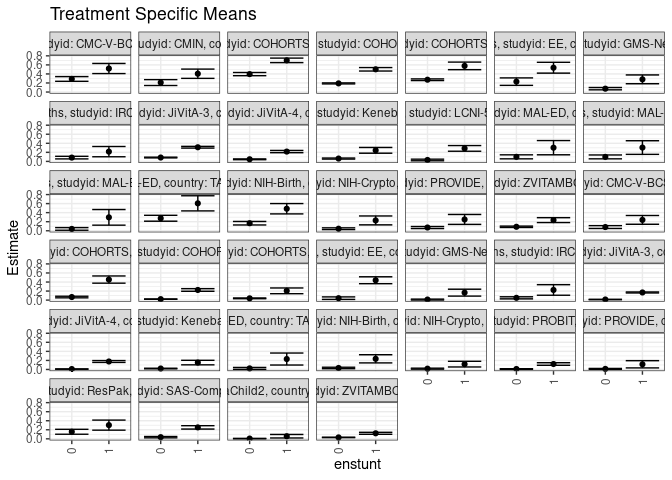

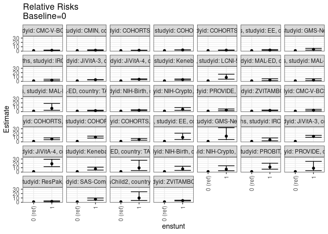

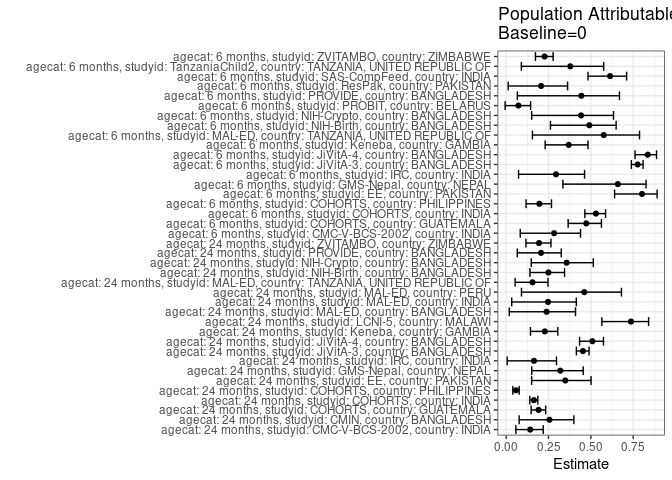

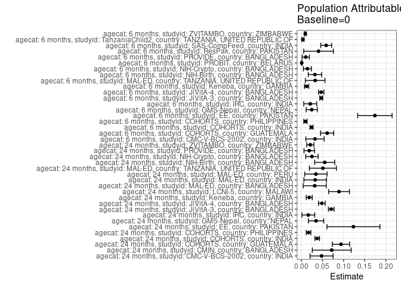

## Results Table

### Parameter: TSM

| agecat | studyid | country | intervention_level | baseline_level | estimate | ci_lower | ci_upper |
| --- | --- | --- | --- | --- | --- | --- | --- |
| 6 months | CMC-V-BCS-2002 | INDIA | 0 | NA | 0.0816327 | 0.0502923 | 0.1129730 |
| 6 months | CMC-V-BCS-2002 | INDIA | 1 | NA | 0.2400000 | 0.1432125 | 0.3367875 |
| 6 months | COHORTS | GUATEMALA | 0 | NA | 0.0679852 | 0.0506304 | 0.0853399 |
| 6 months | COHORTS | GUATEMALA | 1 | NA | 0.4539474 | 0.3747570 | 0.5331377 |
| 6 months | COHORTS | INDIA | 0 | NA | 0.0213294 | 0.0176879 | 0.0249709 |
| 6 months | COHORTS | INDIA | 1 | NA | 0.2241379 | 0.1954531 | 0.2528227 |
| 6 months | COHORTS | PHILIPPINES | 0 | NA | 0.0391850 | 0.0316554 | 0.0467145 |
| 6 months | COHORTS | PHILIPPINES | 1 | NA | 0.2051282 | 0.1417519 | 0.2685046 |
| 6 months | EE | PAKISTAN | 0 | NA | 0.0430622 | 0.0155042 | 0.0706202 |
| 6 months | EE | PAKISTAN | 1 | NA | 0.4390244 | 0.3629698 | 0.5150790 |
| 6 months | GMS-Nepal | NEPAL | 0 | NA | 0.0126850 | 0.0025907 | 0.0227793 |
| 6 months | GMS-Nepal | NEPAL | 1 | NA | 0.1648352 | 0.0885353 | 0.2411350 |
| 6 months | IRC | INDIA | 0 | NA | 0.0502793 | 0.0276155 | 0.0729432 |
| 6 months | IRC | INDIA | 1 | NA | 0.2244898 | 0.1075193 | 0.3414603 |
| 6 months | JiVitA-3 | BANGLADESH | 0 | NA | 0.0135816 | 0.0112262 | 0.0159371 |
| 6 months | JiVitA-3 | BANGLADESH | 1 | NA | 0.1686912 | 0.1581213 | 0.1792611 |
| 6 months | JiVitA-4 | BANGLADESH | 0 | NA | 0.0092086 | 0.0054408 | 0.0129765 |
| 6 months | JiVitA-4 | BANGLADESH | 1 | NA | 0.1762537 | 0.1554013 | 0.1971061 |
| 6 months | Keneba | GAMBIA | 0 | NA | 0.0211416 | 0.0146580 | 0.0276253 |
| 6 months | Keneba | GAMBIA | 1 | NA | 0.1522843 | 0.1020995 | 0.2024690 |
| 6 months | MAL-ED | TANZANIA, UNITED REPUBLIC OF | 0 | NA | 0.0240385 | 0.0031807 | 0.0448962 |
| 6 months | MAL-ED | TANZANIA, UNITED REPUBLIC OF | 1 | NA | 0.2307692 | 0.0982698 | 0.3632687 |
| 6 months | NIH-Birth | BANGLADESH | 0 | NA | 0.0331858 | 0.0166574 | 0.0497143 |
| 6 months | NIH-Birth | BANGLADESH | 1 | NA | 0.2352941 | 0.1450340 | 0.3255543 |
| 6 months | NIH-Crypto | BANGLADESH | 0 | NA | 0.0179445 | 0.0074284 | 0.0284607 |
| 6 months | NIH-Crypto | BANGLADESH | 1 | NA | 0.1176471 | 0.0550774 | 0.1802167 |
| 6 months | PROBIT | BELARUS | 0 | NA | 0.0104193 | 0.0046563 | 0.0161824 |
| 6 months | PROBIT | BELARUS | 1 | NA | 0.1206897 | 0.0927303 | 0.1486490 |
| 6 months | PROVIDE | BANGLADESH | 0 | NA | 0.0128913 | 0.0033954 | 0.0223873 |
| 6 months | PROVIDE | BANGLADESH | 1 | NA | 0.1147541 | 0.0347045 | 0.1948037 |
| 6 months | ResPak | PAKISTAN | 0 | NA | 0.1560694 | 0.1018758 | 0.2102629 |
| 6 months | ResPak | PAKISTAN | 1 | NA | 0.3030303 | 0.1919245 | 0.4141361 |
| 6 months | SAS-CompFeed | INDIA | 0 | NA | 0.0370370 | 0.0224368 | 0.0516373 |
| 6 months | SAS-CompFeed | INDIA | 1 | NA | 0.2527473 | 0.2155600 | 0.2899345 |
| 6 months | TanzaniaChild2 | TANZANIA, UNITED REPUBLIC OF | 0 | NA | 0.0058201 | 0.0023899 | 0.0092503 |
| 6 months | TanzaniaChild2 | TANZANIA, UNITED REPUBLIC OF | 1 | NA | 0.0575540 | 0.0188270 | 0.0962809 |
| 6 months | ZVITAMBO | ZIMBABWE | 0 | NA | 0.0313021 | 0.0274363 | 0.0351680 |
| 6 months | ZVITAMBO | ZIMBABWE | 1 | NA | 0.1224256 | 0.1006938 | 0.1441574 |
| 24 months | CMC-V-BCS-2002 | INDIA | 0 | NA | 0.2891156 | 0.2372242 | 0.3410071 |
| 24 months | CMC-V-BCS-2002 | INDIA | 1 | NA | 0.5194805 | 0.4077353 | 0.6312257 |
| 24 months | CMIN | BANGLADESH | 0 | NA | 0.2091503 | 0.1445733 | 0.2737273 |
| 24 months | CMIN | BANGLADESH | 1 | NA | 0.4044944 | 0.3023178 | 0.5066710 |
| 24 months | COHORTS | GUATEMALA | 0 | NA | 0.3959459 | 0.3606933 | 0.4311985 |
| 24 months | COHORTS | GUATEMALA | 1 | NA | 0.7000000 | 0.6505343 | 0.7494657 |
| 24 months | COHORTS | INDIA | 0 | NA | 0.1910136 | 0.1797695 | 0.2022578 |
| 24 months | COHORTS | INDIA | 1 | NA | 0.5023401 | 0.4636299 | 0.5410503 |
| 24 months | COHORTS | PHILIPPINES | 0 | NA | 0.2722944 | 0.2541380 | 0.2904507 |
| 24 months | COHORTS | PHILIPPINES | 1 | NA | 0.5777778 | 0.4944440 | 0.6611115 |
| 24 months | EE | PAKISTAN | 0 | NA | 0.2300000 | 0.1472703 | 0.3127297 |
| 24 months | EE | PAKISTAN | 1 | NA | 0.5373134 | 0.4175644 | 0.6570625 |
| 24 months | GMS-Nepal | NEPAL | 0 | NA | 0.0738916 | 0.0484199 | 0.0993634 |
| 24 months | GMS-Nepal | NEPAL | 1 | NA | 0.2804878 | 0.1831542 | 0.3778214 |
| 24 months | IRC | INDIA | 0 | NA | 0.0837989 | 0.0550611 | 0.1125366 |
| 24 months | IRC | INDIA | 1 | NA | 0.2156863 | 0.1026675 | 0.3287051 |
| 24 months | JiVitA-3 | BANGLADESH | 0 | NA | 0.0853248 | 0.0773895 | 0.0932601 |
| 24 months | JiVitA-3 | BANGLADESH | 1 | NA | 0.3122677 | 0.2932876 | 0.3312477 |
| 24 months | JiVitA-4 | BANGLADESH | 0 | NA | 0.0468198 | 0.0382615 | 0.0553780 |
| 24 months | JiVitA-4 | BANGLADESH | 1 | NA | 0.2168142 | 0.1920441 | 0.2415842 |
| 24 months | Keneba | GAMBIA | 0 | NA | 0.0626210 | 0.0505522 | 0.0746899 |
| 24 months | Keneba | GAMBIA | 1 | NA | 0.2443182 | 0.1808194 | 0.3078169 |
| 24 months | LCNI-5 | MALAWI | 0 | NA | 0.0318302 | 0.0140945 | 0.0495659 |
| 24 months | LCNI-5 | MALAWI | 1 | NA | 0.2871287 | 0.2246846 | 0.3495728 |
| 24 months | MAL-ED | BANGLADESH | 0 | NA | 0.1005587 | 0.0563971 | 0.1447202 |
| 24 months | MAL-ED | BANGLADESH | 1 | NA | 0.3030303 | 0.1458610 | 0.4601996 |
| 24 months | MAL-ED | INDIA | 0 | NA | 0.0994764 | 0.0569364 | 0.1420165 |
| 24 months | MAL-ED | INDIA | 1 | NA | 0.3055556 | 0.1547493 | 0.4563618 |
| 24 months | MAL-ED | PERU | 0 | NA | 0.0402299 | 0.0109604 | 0.0694993 |
| 24 months | MAL-ED | PERU | 1 | NA | 0.2962963 | 0.1236301 | 0.4689625 |
| 24 months | MAL-ED | TANZANIA, UNITED REPUBLIC OF | 0 | NA | 0.2762431 | 0.2109499 | 0.3415363 |
| 24 months | MAL-ED | TANZANIA, UNITED REPUBLIC OF | 1 | NA | 0.6060606 | 0.4389589 | 0.7731623 |
| 24 months | NIH-Birth | BANGLADESH | 0 | NA | 0.1661972 | 0.1274282 | 0.2049661 |
| 24 months | NIH-Birth | BANGLADESH | 1 | NA | 0.4864865 | 0.3724746 | 0.6004984 |
| 24 months | NIH-Crypto | BANGLADESH | 0 | NA | 0.0450450 | 0.0257345 | 0.0643556 |
| 24 months | NIH-Crypto | BANGLADESH | 1 | NA | 0.2285714 | 0.1301067 | 0.3270362 |
| 24 months | PROVIDE | BANGLADESH | 0 | NA | 0.0714286 | 0.0492311 | 0.0936260 |
| 24 months | PROVIDE | BANGLADESH | 1 | NA | 0.2500000 | 0.1403398 | 0.3596602 |
| 24 months | ZVITAMBO | ZIMBABWE | 0 | NA | 0.0874822 | 0.0727092 | 0.1022552 |
| 24 months | ZVITAMBO | ZIMBABWE | 1 | NA | 0.2350427 | 0.1806971 | 0.2893884 |

### Parameter: E(Y)

| agecat | studyid | country | intervention_level | baseline_level | estimate | ci_lower | ci_upper |
| --- | --- | --- | --- | --- | --- | --- | --- |
| 6 months | CMC-V-BCS-2002 | INDIA | NA | NA | 0.1138211 | 0.0813725 | 0.1462698 |
| 6 months | COHORTS | GUATEMALA | NA | NA | 0.1290323 | 0.1078261 | 0.1502384 |
| 6 months | COHORTS | INDIA | NA | NA | 0.0453353 | 0.0404119 | 0.0502586 |
| 6 months | COHORTS | PHILIPPINES | NA | NA | 0.0487445 | 0.0406327 | 0.0568562 |
| 6 months | EE | PAKISTAN | NA | NA | 0.2171582 | 0.1752594 | 0.2590570 |
| 6 months | GMS-Nepal | NEPAL | NA | NA | 0.0372340 | 0.0215945 | 0.0528736 |
| 6 months | IRC | INDIA | NA | NA | 0.0712531 | 0.0462303 | 0.0962759 |
| 6 months | JiVitA-3 | BANGLADESH | NA | NA | 0.0606746 | 0.0568229 | 0.0645262 |
| 6 months | JiVitA-4 | BANGLADESH | NA | NA | 0.0560960 | 0.0493335 | 0.0628586 |
| 6 months | Keneba | GAMBIA | NA | NA | 0.0335089 | 0.0257898 | 0.0412279 |
| 6 months | MAL-ED | TANZANIA, UNITED REPUBLIC OF | NA | NA | 0.0566802 | 0.0277850 | 0.0855754 |
| 6 months | NIH-Birth | BANGLADESH | NA | NA | 0.0651769 | 0.0442802 | 0.0860736 |
| 6 months | NIH-Crypto | BANGLADESH | NA | NA | 0.0321678 | 0.0192256 | 0.0451101 |
| 6 months | PROBIT | BELARUS | NA | NA | 0.0112310 | 0.0054733 | 0.0169886 |
| 6 months | PROVIDE | BANGLADESH | NA | NA | 0.0231788 | 0.0111688 | 0.0351888 |
| 6 months | ResPak | PAKISTAN | NA | NA | 0.1966527 | 0.1461562 | 0.2471492 |
| 6 months | SAS-CompFeed | INDIA | NA | NA | 0.0958084 | 0.0774939 | 0.1141229 |
| 6 months | TanzaniaChild2 | TANZANIA, UNITED REPUBLIC OF | NA | NA | 0.0093642 | 0.0051724 | 0.0135561 |
| 6 months | ZVITAMBO | ZIMBABWE | NA | NA | 0.0404891 | 0.0363397 | 0.0446385 |
| 24 months | CMC-V-BCS-2002 | INDIA | NA | NA | 0.3369272 | 0.2887662 | 0.3850883 |
| 24 months | CMIN | BANGLADESH | NA | NA | 0.2809917 | 0.2242434 | 0.3377401 |
| 24 months | COHORTS | GUATEMALA | NA | NA | 0.4897196 | 0.4597530 | 0.5196862 |
| 24 months | COHORTS | INDIA | NA | NA | 0.2284055 | 0.2171416 | 0.2396694 |
| 24 months | COHORTS | PHILIPPINES | NA | NA | 0.2891616 | 0.2711872 | 0.3071359 |
| 24 months | EE | PAKISTAN | NA | NA | 0.3532934 | 0.2805798 | 0.4260070 |
| 24 months | GMS-Nepal | NEPAL | NA | NA | 0.1086066 | 0.0809724 | 0.1362407 |
| 24 months | IRC | INDIA | NA | NA | 0.1002445 | 0.0711031 | 0.1293859 |
| 24 months | JiVitA-3 | BANGLADESH | NA | NA | 0.1560473 | 0.1472898 | 0.1648047 |
| 24 months | JiVitA-4 | BANGLADESH | NA | NA | 0.0953283 | 0.0857752 | 0.1048814 |
| 24 months | Keneba | GAMBIA | NA | NA | 0.0811594 | 0.0682689 | 0.0940499 |
| 24 months | LCNI-5 | MALAWI | NA | NA | 0.1208981 | 0.0943206 | 0.1474756 |
| 24 months | MAL-ED | BANGLADESH | NA | NA | 0.1320755 | 0.0863920 | 0.1777589 |
| 24 months | MAL-ED | INDIA | NA | NA | 0.1321586 | 0.0880054 | 0.1763117 |
| 24 months | MAL-ED | PERU | NA | NA | 0.0746269 | 0.0382069 | 0.1110468 |
| 24 months | MAL-ED | TANZANIA, UNITED REPUBLIC OF | NA | NA | 0.3271028 | 0.2640978 | 0.3901078 |
| 24 months | NIH-Birth | BANGLADESH | NA | NA | 0.2214452 | 0.1821080 | 0.2607825 |
| 24 months | NIH-Crypto | BANGLADESH | NA | NA | 0.0700389 | 0.0479542 | 0.0921236 |
| 24 months | PROVIDE | BANGLADESH | NA | NA | 0.0899654 | 0.0666186 | 0.1133122 |
| 24 months | ZVITAMBO | ZIMBABWE | NA | NA | 0.1085366 | 0.0934775 | 0.1235957 |

### Parameter: RR

| agecat | studyid | country | intervention_level | baseline_level | estimate | ci_lower | ci_upper |
| --- | --- | --- | --- | --- | --- | --- | --- |
| 6 months | CMC-V-BCS-2002 | INDIA | 0 | 0 | 1.000000 | 1.000000 | 1.000000 |
| 6 months | CMC-V-BCS-2002 | INDIA | 1 | 0 | 2.940000 | 1.684732 | 5.130549 |
| 6 months | COHORTS | GUATEMALA | 0 | 0 | 1.000000 | 1.000000 | 1.000000 |
| 6 months | COHORTS | GUATEMALA | 1 | 0 | 6.677153 | 4.901323 | 9.096396 |
| 6 months | COHORTS | INDIA | 0 | 0 | 1.000000 | 1.000000 | 1.000000 |
| 6 months | COHORTS | INDIA | 1 | 0 | 10.508420 | 8.489312 | 13.007755 |
| 6 months | COHORTS | PHILIPPINES | 0 | 0 | 1.000000 | 1.000000 | 1.000000 |
| 6 months | COHORTS | PHILIPPINES | 1 | 0 | 5.234872 | 3.638251 | 7.532159 |
| 6 months | EE | PAKISTAN | 0 | 0 | 1.000000 | 1.000000 | 1.000000 |
| 6 months | EE | PAKISTAN | 1 | 0 | 10.195122 | 5.253625 | 19.784531 |
| 6 months | GMS-Nepal | NEPAL | 0 | 0 | 1.000000 | 1.000000 | 1.000000 |
| 6 months | GMS-Nepal | NEPAL | 1 | 0 | 12.994506 | 5.175442 | 32.626618 |
| 6 months | IRC | INDIA | 0 | 0 | 1.000000 | 1.000000 | 1.000000 |
| 6 months | IRC | INDIA | 1 | 0 | 4.464853 | 2.241776 | 8.892463 |
| 6 months | JiVitA-3 | BANGLADESH | 0 | 0 | 1.000000 | 1.000000 | 1.000000 |
| 6 months | JiVitA-3 | BANGLADESH | 1 | 0 | 12.420554 | 10.356235 | 14.896357 |
| 6 months | JiVitA-4 | BANGLADESH | 0 | 0 | 1.000000 | 1.000000 | 1.000000 |
| 6 months | JiVitA-4 | BANGLADESH | 1 | 0 | 19.140049 | 12.472834 | 29.371148 |
| 6 months | Keneba | GAMBIA | 0 | 0 | 1.000000 | 1.000000 | 1.000000 |
| 6 months | Keneba | GAMBIA | 1 | 0 | 7.203046 | 4.592090 | 11.298531 |
| 6 months | MAL-ED | TANZANIA, UNITED REPUBLIC OF | 0 | 0 | 1.000000 | 1.000000 | 1.000000 |
| 6 months | MAL-ED | TANZANIA, UNITED REPUBLIC OF | 1 | 0 | 9.600000 | 3.391639 | 27.172703 |
| 6 months | NIH-Birth | BANGLADESH | 0 | 0 | 1.000000 | 1.000000 | 1.000000 |
| 6 months | NIH-Birth | BANGLADESH | 1 | 0 | 7.090196 | 3.781243 | 13.294804 |
| 6 months | NIH-Crypto | BANGLADESH | 0 | 0 | 1.000000 | 1.000000 | 1.000000 |
| 6 months | NIH-Crypto | BANGLADESH | 1 | 0 | 6.556150 | 2.971351 | 14.465844 |
| 6 months | PROBIT | BELARUS | 0 | 0 | 1.000000 | 1.000000 | 1.000000 |
| 6 months | PROBIT | BELARUS | 1 | 0 | 11.583245 | 6.597572 | 20.336508 |
| 6 months | PROVIDE | BANGLADESH | 0 | 0 | 1.000000 | 1.000000 | 1.000000 |
| 6 months | PROVIDE | BANGLADESH | 1 | 0 | 8.901639 | 3.227583 | 24.550630 |
| 6 months | ResPak | PAKISTAN | 0 | 0 | 1.000000 | 1.000000 | 1.000000 |
| 6 months | ResPak | PAKISTAN | 1 | 0 | 1.941639 | 1.171810 | 3.217211 |
| 6 months | SAS-CompFeed | INDIA | 0 | 0 | 1.000000 | 1.000000 | 1.000000 |
| 6 months | SAS-CompFeed | INDIA | 1 | 0 | 6.824176 | 4.815626 | 9.670472 |
| 6 months | TanzaniaChild2 | TANZANIA, UNITED REPUBLIC OF | 0 | 0 | 1.000000 | 1.000000 | 1.000000 |
| 6 months | TanzaniaChild2 | TANZANIA, UNITED REPUBLIC OF | 1 | 0 | 9.888816 | 4.042664 | 24.189171 |
| 6 months | ZVITAMBO | ZIMBABWE | 0 | 0 | 1.000000 | 1.000000 | 1.000000 |
| 6 months | ZVITAMBO | ZIMBABWE | 1 | 0 | 3.911097 | 3.150533 | 4.855268 |
| 24 months | CMC-V-BCS-2002 | INDIA | 0 | 0 | 1.000000 | 1.000000 | 1.000000 |
| 24 months | CMC-V-BCS-2002 | INDIA | 1 | 0 | 1.796791 | 1.357776 | 2.377755 |
| 24 months | CMIN | BANGLADESH | 0 | 0 | 1.000000 | 1.000000 | 1.000000 |
| 24 months | CMIN | BANGLADESH | 1 | 0 | 1.933989 | 1.297787 | 2.882069 |
| 24 months | COHORTS | GUATEMALA | 0 | 0 | 1.000000 | 1.000000 | 1.000000 |
| 24 months | COHORTS | GUATEMALA | 1 | 0 | 1.767918 | 1.577962 | 1.980742 |
| 24 months | COHORTS | INDIA | 0 | 0 | 1.000000 | 1.000000 | 1.000000 |
| 24 months | COHORTS | INDIA | 1 | 0 | 2.629865 | 2.386819 | 2.897660 |
| 24 months | COHORTS | PHILIPPINES | 0 | 0 | 1.000000 | 1.000000 | 1.000000 |
| 24 months | COHORTS | PHILIPPINES | 1 | 0 | 2.121887 | 1.810145 | 2.487316 |
| 24 months | EE | PAKISTAN | 0 | 0 | 1.000000 | 1.000000 | 1.000000 |
| 24 months | EE | PAKISTAN | 1 | 0 | 2.336145 | 1.530141 | 3.566714 |
| 24 months | GMS-Nepal | NEPAL | 0 | 0 | 1.000000 | 1.000000 | 1.000000 |
| 24 months | GMS-Nepal | NEPAL | 1 | 0 | 3.795935 | 2.327510 | 6.190790 |
| 24 months | IRC | INDIA | 0 | 0 | 1.000000 | 1.000000 | 1.000000 |
| 24 months | IRC | INDIA | 1 | 0 | 2.573856 | 1.375977 | 4.814568 |
| 24 months | JiVitA-3 | BANGLADESH | 0 | 0 | 1.000000 | 1.000000 | 1.000000 |
| 24 months | JiVitA-3 | BANGLADESH | 1 | 0 | 3.659752 | 3.287041 | 4.074724 |
| 24 months | JiVitA-4 | BANGLADESH | 0 | 0 | 1.000000 | 1.000000 | 1.000000 |
| 24 months | JiVitA-4 | BANGLADESH | 1 | 0 | 4.630823 | 3.722008 | 5.761546 |
| 24 months | Keneba | GAMBIA | 0 | 0 | 1.000000 | 1.000000 | 1.000000 |
| 24 months | Keneba | GAMBIA | 1 | 0 | 3.901535 | 2.823019 | 5.392091 |
| 24 months | LCNI-5 | MALAWI | 0 | 0 | 1.000000 | 1.000000 | 1.000000 |
| 24 months | LCNI-5 | MALAWI | 1 | 0 | 9.020627 | 4.959869 | 16.406020 |
| 24 months | MAL-ED | BANGLADESH | 0 | 0 | 1.000000 | 1.000000 | 1.000000 |
| 24 months | MAL-ED | BANGLADESH | 1 | 0 | 3.013468 | 1.527269 | 5.945901 |
| 24 months | MAL-ED | INDIA | 0 | 0 | 1.000000 | 1.000000 | 1.000000 |
| 24 months | MAL-ED | INDIA | 1 | 0 | 3.071637 | 1.598664 | 5.901777 |
| 24 months | MAL-ED | PERU | 0 | 0 | 1.000000 | 1.000000 | 1.000000 |
| 24 months | MAL-ED | PERU | 1 | 0 | 7.365079 | 2.899635 | 18.707319 |
| 24 months | MAL-ED | TANZANIA, UNITED REPUBLIC OF | 0 | 0 | 1.000000 | 1.000000 | 1.000000 |
| 24 months | MAL-ED | TANZANIA, UNITED REPUBLIC OF | 1 | 0 | 2.193939 | 1.525826 | 3.154599 |
| 24 months | NIH-Birth | BANGLADESH | 0 | 0 | 1.000000 | 1.000000 | 1.000000 |
| 24 months | NIH-Birth | BANGLADESH | 1 | 0 | 2.927164 | 2.103010 | 4.074298 |
| 24 months | NIH-Crypto | BANGLADESH | 0 | 0 | 1.000000 | 1.000000 | 1.000000 |
| 24 months | NIH-Crypto | BANGLADESH | 1 | 0 | 5.074286 | 2.763345 | 9.317830 |
| 24 months | PROVIDE | BANGLADESH | 0 | 0 | 1.000000 | 1.000000 | 1.000000 |
| 24 months | PROVIDE | BANGLADESH | 1 | 0 | 3.500000 | 2.044584 | 5.991440 |
| 24 months | ZVITAMBO | ZIMBABWE | 0 | 0 | 1.000000 | 1.000000 | 1.000000 |
| 24 months | ZVITAMBO | ZIMBABWE | 1 | 0 | 2.686749 | 2.017814 | 3.577444 |

### Parameter: PAR

| agecat | studyid | country | intervention_level | baseline_level | estimate | ci_lower | ci_upper |
| --- | --- | --- | --- | --- | --- | --- | --- |
| 6 months | CMC-V-BCS-2002 | INDIA | 0 | NA | 0.0321885 | 0.0105097 | 0.0538673 |
| 6 months | COHORTS | GUATEMALA | 0 | NA | 0.0610471 | 0.0454333 | 0.0766609 |
| 6 months | COHORTS | INDIA | 0 | NA | 0.0240059 | 0.0202485 | 0.0277633 |
| 6 months | COHORTS | PHILIPPINES | 0 | NA | 0.0095595 | 0.0056049 | 0.0135141 |
| 6 months | EE | PAKISTAN | 0 | NA | 0.1740960 | 0.1333052 | 0.2148868 |
| 6 months | GMS-Nepal | NEPAL | 0 | NA | 0.0245491 | 0.0112983 | 0.0377998 |
| 6 months | IRC | INDIA | 0 | NA | 0.0209737 | 0.0056059 | 0.0363416 |
| 6 months | JiVitA-3 | BANGLADESH | 0 | NA | 0.0470929 | 0.0436491 | 0.0505368 |
| 6 months | JiVitA-4 | BANGLADESH | 0 | NA | 0.0468874 | 0.0406071 | 0.0531677 |
| 6 months | Keneba | GAMBIA | 0 | NA | 0.0123672 | 0.0073200 | 0.0174144 |
| 6 months | MAL-ED | TANZANIA, UNITED REPUBLIC OF | 0 | NA | 0.0326417 | 0.0094626 | 0.0558208 |
| 6 months | NIH-Birth | BANGLADESH | 0 | NA | 0.0319911 | 0.0161807 | 0.0478014 |
| 6 months | NIH-Crypto | BANGLADESH | 0 | NA | 0.0142233 | 0.0048177 | 0.0236289 |
| 6 months | PROBIT | BELARUS | 0 | NA | 0.0008116 | 0.0000531 | 0.0015701 |
| 6 months | PROVIDE | BANGLADESH | 0 | NA | 0.0102875 | 0.0017857 | 0.0187892 |
| 6 months | ResPak | PAKISTAN | 0 | NA | 0.0405834 | 0.0054404 | 0.0757264 |
| 6 months | SAS-CompFeed | INDIA | 0 | NA | 0.0587713 | 0.0458331 | 0.0717096 |
| 6 months | TanzaniaChild2 | TANZANIA, UNITED REPUBLIC OF | 0 | NA | 0.0035441 | 0.0008206 | 0.0062676 |
| 6 months | ZVITAMBO | ZIMBABWE | 0 | NA | 0.0091870 | 0.0068879 | 0.0114861 |
| 24 months | CMC-V-BCS-2002 | INDIA | 0 | NA | 0.0478116 | 0.0205261 | 0.0750971 |
| 24 months | CMIN | BANGLADESH | 0 | NA | 0.0718414 | 0.0258249 | 0.1178579 |
| 24 months | COHORTS | GUATEMALA | 0 | NA | 0.0937737 | 0.0732358 | 0.1143116 |
| 24 months | COHORTS | INDIA | 0 | NA | 0.0373918 | 0.0318408 | 0.0429428 |
| 24 months | COHORTS | PHILIPPINES | 0 | NA | 0.0168672 | 0.0114057 | 0.0223287 |
| 24 months | EE | PAKISTAN | 0 | NA | 0.1232934 | 0.0605653 | 0.1860215 |
| 24 months | GMS-Nepal | NEPAL | 0 | NA | 0.0347149 | 0.0164700 | 0.0529599 |
| 24 months | IRC | INDIA | 0 | NA | 0.0164456 | 0.0013022 | 0.0315890 |
| 24 months | JiVitA-3 | BANGLADESH | 0 | NA | 0.0707225 | 0.0640429 | 0.0774021 |
| 24 months | JiVitA-4 | BANGLADESH | 0 | NA | 0.0485085 | 0.0406415 | 0.0563755 |
| 24 months | Keneba | GAMBIA | 0 | NA | 0.0185384 | 0.0114511 | 0.0256257 |
| 24 months | LCNI-5 | MALAWI | 0 | NA | 0.0890679 | 0.0643436 | 0.1137921 |
| 24 months | MAL-ED | BANGLADESH | 0 | NA | 0.0315168 | 0.0042425 | 0.0587911 |
| 24 months | MAL-ED | INDIA | 0 | NA | 0.0326822 | 0.0059645 | 0.0593998 |
| 24 months | MAL-ED | PERU | 0 | NA | 0.0343970 | 0.0079419 | 0.0608520 |
| 24 months | MAL-ED | TANZANIA, UNITED REPUBLIC OF | 0 | NA | 0.0508597 | 0.0189028 | 0.0828166 |
| 24 months | NIH-Birth | BANGLADESH | 0 | NA | 0.0552480 | 0.0315222 | 0.0789739 |
| 24 months | NIH-Crypto | BANGLADESH | 0 | NA | 0.0249939 | 0.0102832 | 0.0397045 |
| 24 months | PROVIDE | BANGLADESH | 0 | NA | 0.0185368 | 0.0061013 | 0.0309723 |
| 24 months | ZVITAMBO | ZIMBABWE | 0 | NA | 0.0210544 | 0.0126393 | 0.0294694 |

### Parameter: PAF

| agecat | studyid | country | intervention_level | baseline_level | estimate | ci_lower | ci_upper |
| --- | --- | --- | --- | --- | --- | --- | --- |
| 6 months | CMC-V-BCS-2002 | INDIA | 0 | NA | 0.2827988 | 0.0833300 | 0.4388629 |
| 6 months | COHORTS | GUATEMALA | 0 | NA | 0.4731150 | 0.3657983 | 0.5622720 |
| 6 months | COHORTS | INDIA | 0 | NA | 0.5295195 | 0.4644904 | 0.5866518 |
| 6 months | COHORTS | PHILIPPINES | 0 | NA | 0.1961148 | 0.1176543 | 0.2675983 |
| 6 months | EE | PAKISTAN | 0 | NA | 0.8017012 | 0.6399535 | 0.8907852 |
| 6 months | GMS-Nepal | NEPAL | 0 | NA | 0.6593174 | 0.3347627 | 0.8255290 |
| 6 months | IRC | INDIA | 0 | NA | 0.2943556 | 0.0732693 | 0.4626983 |
| 6 months | JiVitA-3 | BANGLADESH | 0 | NA | 0.7761563 | 0.7388470 | 0.8081354 |
| 6 months | JiVitA-4 | BANGLADESH | 0 | NA | 0.8358417 | 0.7606221 | 0.8874251 |
| 6 months | Keneba | GAMBIA | 0 | NA | 0.3690728 | 0.2301006 | 0.4829595 |
| 6 months | MAL-ED | TANZANIA, UNITED REPUBLIC OF | 0 | NA | 0.5758929 | 0.1551277 | 0.7871076 |
| 6 months | NIH-Birth | BANGLADESH | 0 | NA | 0.4908344 | 0.2615395 | 0.6489323 |
| 6 months | NIH-Crypto | BANGLADESH | 0 | NA | 0.4421590 | 0.1505775 | 0.6336492 |
| 6 months | PROBIT | BELARUS | 0 | NA | 0.0722676 | -0.0059525 | 0.1444054 |
| 6 months | PROVIDE | BANGLADESH | 0 | NA | 0.4438306 | 0.0662412 | 0.6687320 |
| 6 months | ResPak | PAKISTAN | 0 | NA | 0.2063707 | 0.0120273 | 0.3624849 |
| 6 months | SAS-CompFeed | INDIA | 0 | NA | 0.6134259 | 0.4830009 | 0.7109482 |
| 6 months | TanzaniaChild2 | TANZANIA, UNITED REPUBLIC OF | 0 | NA | 0.3784740 | 0.0897894 | 0.5755986 |
| 6 months | ZVITAMBO | ZIMBABWE | 0 | NA | 0.2269001 | 0.1729582 | 0.2773239 |
| 24 months | CMC-V-BCS-2002 | INDIA | 0 | NA | 0.1419048 | 0.0573348 | 0.2188877 |
| 24 months | CMIN | BANGLADESH | 0 | NA | 0.2556709 | 0.0767711 | 0.3999042 |
| 24 months | COHORTS | GUATEMALA | 0 | NA | 0.1914844 | 0.1474977 | 0.2332015 |
| 24 months | COHORTS | INDIA | 0 | NA | 0.1637082 | 0.1397550 | 0.1869944 |
| 24 months | COHORTS | PHILIPPINES | 0 | NA | 0.0583313 | 0.0393364 | 0.0769507 |
| 24 months | EE | PAKISTAN | 0 | NA | 0.3489831 | 0.1504168 | 0.5011400 |
| 24 months | GMS-Nepal | NEPAL | 0 | NA | 0.3196394 | 0.1509758 | 0.4547969 |
| 24 months | IRC | INDIA | 0 | NA | 0.1640550 | 0.0059462 | 0.2970160 |
| 24 months | JiVitA-3 | BANGLADESH | 0 | NA | 0.4532118 | 0.4145806 | 0.4892938 |
| 24 months | JiVitA-4 | BANGLADESH | 0 | NA | 0.5088573 | 0.4333245 | 0.5743223 |
| 24 months | Keneba | GAMBIA | 0 | NA | 0.2284193 | 0.1435101 | 0.3049109 |
| 24 months | LCNI-5 | MALAWI | 0 | NA | 0.7367185 | 0.5649037 | 0.8406854 |
| 24 months | MAL-ED | BANGLADESH | 0 | NA | 0.2386273 | 0.0184224 | 0.4094319 |
| 24 months | MAL-ED | INDIA | 0 | NA | 0.2472949 | 0.0328301 | 0.4142033 |
| 24 months | MAL-ED | PERU | 0 | NA | 0.4609195 | 0.0905879 | 0.6804444 |
| 24 months | MAL-ED | TANZANIA, UNITED REPUBLIC OF | 0 | NA | 0.1554854 | 0.0528389 | 0.2470078 |
| 24 months | NIH-Birth | BANGLADESH | 0 | NA | 0.2494885 | 0.1405157 | 0.3446448 |
| 24 months | NIH-Crypto | BANGLADESH | 0 | NA | 0.3568569 | 0.1481168 | 0.5144486 |
| 24 months | PROVIDE | BANGLADESH | 0 | NA | 0.2060440 | 0.0657221 | 0.3252905 |
| 24 months | ZVITAMBO | ZIMBABWE | 0 | NA | 0.1939840 | 0.1168296 | 0.2643983 |